# Workflow Hub for Automated Metagenomic Exploration (WHAM!)

## 5.3 FeatureHeatmap

The usage of `FeatureHeatmap()` is more simple than TaxaHeatmap without specifying taxonomic rank information. Three options “all”, “custom” and “DE.filter” are also implanted. There is also the `scale` argument and arguments from the ComplexHeatmap package.

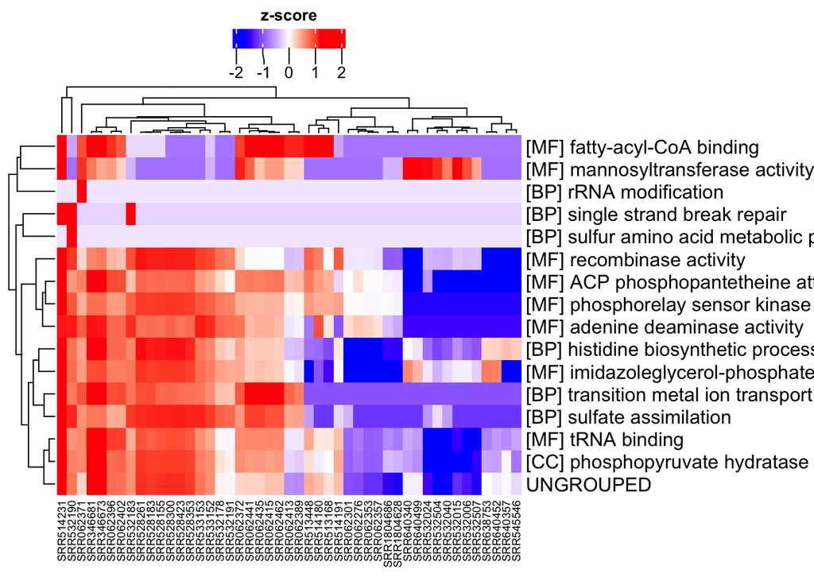

```r
 wham_bbk_feature <-  WhamBiobakery(countData = countData,
                         colData = metadata, ##required, choose feautre(gene family)
                         DE = "feature",
                         design = ~ Location,    ##design formula to let function conduct tests on the group of interest,
                         ref.contrast = c("Location","Arm")
                         )

FeatureHeatmap(wham_bbk_feature,
               filter = "DE.filter",
               scale = T,
               column_names_gp = grid::gpar(fontsize = 7))
```

## 5.4 FeatureCorr

Functional pathway correlation exploration can be realized via the `FeatureCorr()`. This part helps users establish the correlation among genes. This function needs two kinds of information: features and samples. Users can claim them via function argument:`feature` and `group`as needed ,otherwise, user can use the features and samples from the differential analysis results. In the output plot, star sign means statistic significance. “*" < 0.05,"**"<0.01,"***” < 0.001. Users can aslo choose correlation method and p value adjustment method as needed.

```r
FeatureCorr(wham_bbk_feature,
            UseDE.result = T, ## we use results from differential analysis
            effect.size.range = c(-1.5,1.5),
            )
```

```
#> Correlation test will be based on the samples and features in the DE.result. (The we.eHB cutoff and effect size cutoff can be adjusted via parameter we.eHB.cutoff and effect.size.range)
#> All samples will be used for correlation
#> features:(totally 0)  is/are removed because the standard deviations of these feature(s) are Zero
```

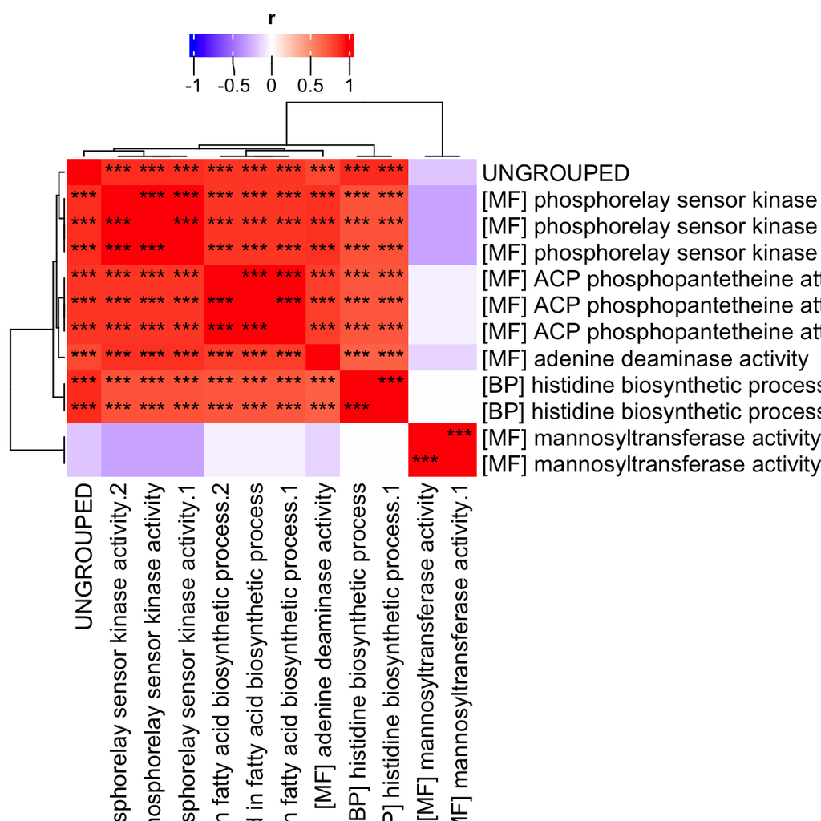

```r
feature_selection = wham_bbk_feature@DE.result$name[1:10] ##select first 10 pathways
sample_selection = rownames(wham_bbk@colData)[1:25] ##select fist 25 samples
FeatureCorr(wham_bbk_feature,
            feature = feature_selection,
            group = sample_selection
            )
```

```
#> Correlation test will be in process of calculation via using samples and  declaimed features
#> features:(totally 1) [BP] rRNA modification is/are removed because the standard deviations of these feature(s) are Zero
```

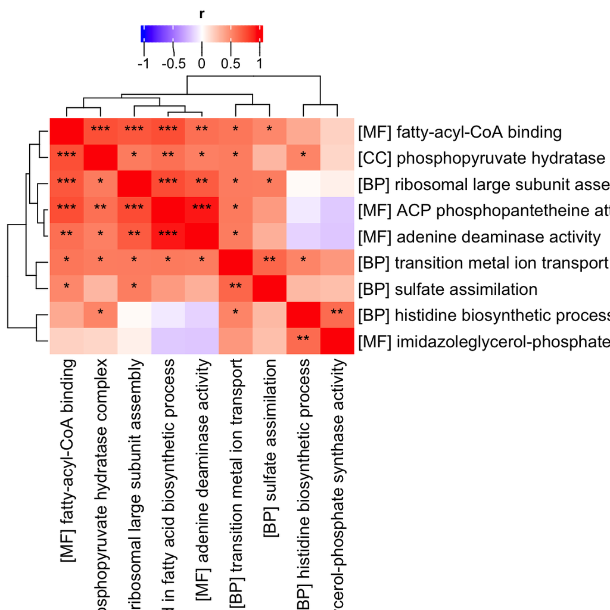

# 6.reference

Fernandes, AD, Macklaim, JM, Linn, TG, Reid, G, Gloor, GB (2013). “*** ANOVA-Like Differential Gene Expression Analysis of Single-Organism and Meta-RNA-Seq.” *** PLoS ONE, 2013, volume 8, issue 7, e67019. <URL: *** http://dx.doi.org/10.1371%2/journal.pone.0067019>.

Fernandes, D. A, Reid, J., Macklaim, M. J, McMurrough, T.A, Edgell, D.R., Gloor, B. G (2014). “*** Unifying the analysis of high-throughput sequencing datasets: characterizing RNA-seq, 16S rRNA gene sequencing and selective growth experiments by compositional data analysis.” *** Microbiome, 2014, volume 2, 15 . <URL: *** http://doi:10.1186/2049-2618-2-15>.

Gloor GB, Macklaim JM, Fernandes AD (2016). “*** Displaying Variation in Large Datasets: a Visual Summary of Effect Sizes.” *** Journal of Computational and Graphical Statistics, . <URL: *** http://dx.doi.org/10.1080/10618600.2015.1131161>.

H. Wickham. ggplot2: Elegant Graphics for Data Analysis. Springer-Verlag New York, 2016.

Gu, Z. (2016) Complex heatmaps reveal patterns and correlations in multidimensional genomic data. Bioinformatics.

phyloseq: An R package for reproducible interactive analysis and graphics of microbiome census data. Paul J. McMurdie and Susan Holmes (2013) PLoS ONE 8(4):e61217.

Martin Morgan, Valerie Obenchain, Jim Hester and Hervé Pagès (2020). SummarizedExperiment: SummarizedExperiment container. R package version 1.20.0. https://bioconductor.org/packages/SummarizedExperiment